# The Birthday Paradox

Vassilis Markos

# The Birthday Paradox

The “Paradox” goes like that:

> In a room of $n$ people what is the minimum value of $n$ such that at least two people in that room share birthdays?

## Some Initial Thoughts

To begin with, $n=1$ is not the answer, since a single person cannot share birthday with anybody else in the room. In the same way, we should not consider values of $n$ greater than 365, assuming no leap years for a moment. So, we are left with:

$$n\in\{2,3,\ldots,365\}.$$

## A Simulation

We can simulate a room of $n$ people as a list of $n$ numbers ranging from 1 up to 365, with each number corresponding to the day each person has been born. So, whenever we have a sample containing at least one pair of duplicates, we have two people in that room sharing birthday.

Now, in order to actually estimate the corresponding probability, we just have to repeat the above many times.

```
bday_simulation <- function() {
  N <- 100
  for (n in 2:365) {
    hits <- 0
    for (i in 1:N) {
      room <- sample(1:365, n, replace = TRUE)
      dedup <- unique(room)
      if (length(dedup) < length(room)) {
        # This means there are some duplicates, so some people share birthday
        hits <- hits + 1
      }
    }
    prob_same_bday = hits / N
    if (prob_same_bday > 0.50) {
      return(n)
    }
  }
  return(366)
}
results <- c() # c() constructs an empty vector (column)
for (i in 1:100) {
  results[i] <- bday_simulation()
}
res_table <- table(results)
print(res_table)
```

```
results
19 20 21 22 23 24 25 26
 1  2 15 28 32 17  4  1
```

```
barplot(res_table)
```

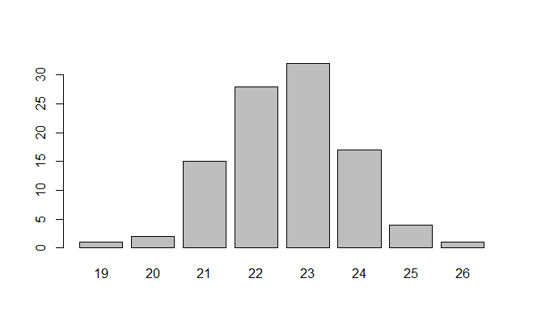

## For the next time…

What is the actual value of $n$ using probability theory? Of course, you can use R to facilitate any computations!